# TRABAJO FINAL ML

## Modelos

**Victor Fernandez-Jimenez & Hugo Pasqual del Pobil**

CUNEF 2021-2022

Machine Learning

## Explicabilidad

Explicabilidad e interpretabilidad a un modelo de RandomForestClassifier usando la librería de Python Shap.

Del análisis de los modelos podemos obtener:

1. Características más importantes (features)
2. Para una predicción en particular del modelo, el efecto que tuvo en ella cada característica
3. Efecto de cada característica en el global de las predicciones del modelo

¿Cuales de las features piensa el modelo que son más importantes? ¿Qué Características tienen mayor impacto en las predicciones? Estos conceptos son conocidos como “Feature Importante” y “Permutation Importance” y nos sirven para calcular nuestras características de entrada al modelo. Nos sirve para poder ver cuando nuestro modelo está funcionando de manera contra-intuitiva y también para demostrar a terceros cuando el funcionamiento es correcto.

Para hacer Permutation Importante debemos primero entrenar un modelo y “encajarlo” (fit). Luego tomamos el set de validación y tomamos las features una por vez: por ejemplo, tomamos la primer columna de entrada y mezclamos todos sus valores entre sus filas (pero el resto de features se mantienen igual).

#### Librerías

```python
import pandas as pd
import numpy as np
import shap
import lightgbm as lgb
shap.initjs()
import warnings
import matplotlib.pyplot as plt
from sklearn.utils import resample
from sklearn.preprocessing import LabelEncoder
from sklearn.model_selection import train_test_split, cross_val_score, GridSearchCV
from sklearn.ensemble import RandomForestClassifier
warnings.filterwarnings("ignore")

# Opciones de viasualización
pd.set_option('display.max_columns', 500)
pd.set_option('display.max_rows', 500)
```

#### Importación de los datos

```python
# Importamos los datos
df = pd.read_csv('NCDB_1999_to_2014_1.csv')

# De que tipo son los datos?
print(type(df))
```

```
<class 'pandas.core.frame.DataFrame'>
```

Reducimos la dimensión de los datos para poder computar la explicabilidad:

```python
df
```

|  | C_YEAR | C_MNTH | C_WDAY | C_HOUR | C_SEV | C_VEHS | C_CONF | C_RCFG | C_WTHR | C_RSUR | C_RALN | C_TRAF | V_ID | V_TYPE | V_YEAR | P_ID | P_SEX | P_AGE | P_PSN | P_ISEV | P_SAFE | P_USER |
| --- | --- | --- | --- | --- | --- | --- | --- | --- | --- | --- | --- | --- | --- | --- | --- | --- | --- | --- | --- | --- | --- | --- |
| 0 | 1999 | 1 | 1 | 20 | 2 | 02 | 34 | UU | 1 | 5 | 3 | 03 | 01 | 06 | 1990 | 01 | M | 41 | 11 | 1 | UU | 1 |
| 1 | 1999 | 1 | 1 | 20 | 2 | 02 | 34 | UU | 1 | 5 | 3 | 03 | 02 | 01 | 1987 | 01 | M | 19 | 11 | 1 | UU | 1 |
| 2 | 1999 | 1 | 1 | 20 | 2 | 02 | 34 | UU | 1 | 5 | 3 | 03 | 02 | 01 | 1987 | 02 | F | 20 | 13 | 2 | 02 | 2 |
| 3 | 1999 | 1 | 1 | 08 | 2 | 01 | 01 | UU | 5 | 3 | 6 | 18 | 01 | 01 | 1986 | 01 | M | 46 | 11 | 1 | UU | 1 |
| 4 | 1999 | 1 | 1 | 08 | 2 | 01 | 01 | UU | 5 | 3 | 6 | 18 | 99 | NN | NNNN | 01 | M | 05 | 99 | 2 | UU | 3 |
| ... | ... | ... | ... | ... | ... | ... | ... | ... | ... | ... | ... | ... | ... | ... | ... | ... | ... | ... | ... | ... | ... | ... |
| 5860400 | 2014 | UU | U | UU | 2 | UU | UU | 01 | U | U | U | UU | 13 | 07 | UUUU | 01 | M | 24 | 11 | 1 | NN | 1 |
| 5860401 | 2014 | UU | U | 23 | 2 | 01 | 06 | 05 | 1 | 1 | U | 18 | 1 | 14 | 2006 | 01 | M | 29 | 96 | 2 | 09 | 5 |
| 5860402 | 2014 | UU | U | 14 | 2 | 01 | 02 | 01 | 1 | 5 | 4 | 18 | 1 | 01 | 2006 | 01 | F | UU | 11 | 2 | 01 | 1 |
| 5860403 | 2014 | UU | U | 22 | 1 | 01 | 06 | 01 | 2 | 4 | Q | 18 | 1 | 22 | UUUU | 01 | M | 67 | 12 | 3 | 01 | U |
| 5860404 | 2014 | UU | U | 22 | 1 | 01 | 06 | 01 | 2 | 4 | Q | 18 | 1 | 22 | UUUU | 02 | M | 10 | 98 | 1 | 01 | U |

5860405 rows × 22 columns

```python
df = df.sample(n=100000)
```

```python
print(df['C_SEV'].value_counts())
```

```
2    98298
1     1702
Name: C_SEV, dtype: int64
```

## Transformación de los datos

En primer lugar, se transforma el nombre de las columnas a minúsculas.

```python
df.columns = df.columns.map(lambda x: x[:].lower())
```

A continucación, vamos a comprobar qué columnas tienen valores únicos duplicados por ser de tipos diferentes (enteros y texto).

```python
for i in df.columns:
    print(i)
    print('Valores únicos: ', df[i].unique())
    print('NAs: ', df[i].isna().sum())
    print('-------------------------------------------------------')
```

```
c_year
Valores únicos:  [2003 2002 2006 2010 1999 2009 2005 2014 2007 2012 2001 2008 2013 2011
 2000 2004]
NAs:  0
-------------------------------------------------------
c_mnth
Valores únicos:  [12 10 7 11 1 5 9 3 4 6 2 '01' 8 '12' '02' 'UU' '11']
NAs:  0
-------------------------------------------------------
c_wday
Valores únicos:  [4 '7' '1' 7 '5' '2' 3 2 '6' 1 '3' '4' 6 5 'U']
NAs:  0
-------------------------------------------------------
c_hour
Valores únicos:  ['08' '13' '16' '00' '15' '09' '14' '12' '17' '04' '23' '19' '06' '07'
 '11' '18' '10' '20' '02' '03' '22' '05' 'UU' '21' '01']
NAs:  0
-------------------------------------------------------
c_sev
Valores únicos:  [1 2]
NAs:  0
-------------------------------------------------------
c_vehs
Valores únicos:  [2 '03' '02' 1 '01' 3 6 '05' '04' 4 5 '06' '07' 'UU' 36 '09' '08' 7 16
 '30' 9 19 '77' 18 10 '29' '11' 8 '12' '17' 13 '14' 15 12 '34' '20' '26'
 '71' 57 25 '10' '21' '15' '19' '27' 14 35 17 21 '18' '38' '22' 77 33 28
 11 '13' '32' 72 24]
NAs:  0
-------------------------------------------------------
c_conf
Valores únicos:  ['31' '36' '21' '35' '34' '03' '01' 'QQ' '06' '22' '04' '33' '02' '24'
 'UU' '41' '32' '23' '25' '05']
NAs:  0
-------------------------------------------------------
c_rcfg
Valores únicos:  ['01' '02' 'UU' '05' '03' 'QQ' '04' '08' '06' '07' '10' '09']
NAs:  0
-------------------------------------------------------
c_wthr
Valores únicos:  ['3' '1' 'U' '2' '4' '6' '5' '7' 'Q']
```

[output cut: 61 more lines]

```
 '31' '97']
NAs:  0
-------------------------------------------------------
p_isev
Valores únicos:  ['3' '2' '1' 'N' 'U']
NAs:  0
-------------------------------------------------------
p_safe
Valores únicos:  ['02' 'UU' '13' 'NN' '01' 'QQ' '09' '12' '10']
NAs:  0
-------------------------------------------------------
p_user
Valores únicos:  ['1' '2' 'U' '3' '4' '5']
NAs:  0
-------------------------------------------------------
```

```python
df.dropna(subset=['c_vehs'], inplace=True)
```

```python
def join_repeated_values(column):
    '''
    Función que transforma los valores numéricos de la columna introducida a número entero para eliminar los posibles ceros
    que tengan a la izquierda, para posteriormente transformarlos a texto y que todos tengan el mismo formato que los valores
    no númericos y desconocidos.

    :param column: nombre de la columna a transformar en formato texto
    '''
    non_numeric_values = ['Q', 'U', 'N', 'QQ', 'UU', 'NN', 'UUUU', 'NNNN']
    column[~column.isin(non_numeric_values)] = column[~column.isin(non_numeric_values)].astype(int)
    column = column.astype(str)
    return column
```

```python
for i in ['c_mnth', 'c_wday', 'c_vehs', 'v_id']:
    df[i] = join_repeated_values(df[i])
```

Por último, transformamos la variable objetivo c_sev para que se corresponda a los valores de una variable lógica con 0 y 1, siendo 1 si existe al menos un fallecimiento, y 0 en caso contrario

```python
# Sustituimos los valores 2 por 0 para crear la variable objetivo
df['c_sev'] = df['c_sev'].replace(to_replace=2, value=0)
print(df['c_sev'].unique())
print(df['c_sev'].value_counts())
```

```
[1 0]
0    98298
1     1702
Name: c_sev, dtype: int64
```

```python
p_age_uu_nn = df.p_age[df.p_age.isin(['UU','NN'])].count()
```

```python
p_age_uu_values = np.around(np.random.uniform(low=18, high=28, size=p_age_uu_nn))
```

```python
df.p_age[df.p_age.isin(['UU', 'NN'])] = p_age_uu_values
df.p_age = df.p_age.astype(int)
```

## Preparación de los datos para los modelos

### Selección de variables para el modelo

En primer lugar, vamos a seleccionar las variables que se van a utilizar en el primer modelo. Con este modelo, dado un accidente, se quiere predecir si va a existir al menos un fallecimiento o no. Por ello, las variables independientes van a ser aquellas que tengamos disponibles en el momento en que nos avisan del accidente, y la variable dependiente es c_sev, que indica si ha habido fallecimientos o no.

```python
df_model = df[['c_mnth', 'c_raln', 'c_rcfg', 'c_wday', 'c_conf',
               'c_hour', 'c_vehs', 'c_wthr', 'v_type', 'p_psn', 'p_user',  'p_sex', 'c_sev','c_year', 'p_age']]
```

```python
categorical = ['c_mnth', 'c_raln', 'c_rcfg', 'c_wday', 'c_conf',
               'c_hour', 'c_vehs', 'c_wthr', 'v_type', 'p_psn', 'p_user',  'p_sex']
numerical = ['c_year', 'p_age']
```

```python
df_major = df_model[df_model.c_sev == 0]
df_minor = df_model[df_model.c_sev == 1]
```

```python
df_major = df_major.sample(n=90000, random_state=12345)
```

```python
df_model = pd.concat([df_minor, df_major])
```

### Separación del dataset en train y test

Para poder entrenar nuestros modelos y evaluarlos, realizaremos una separación de los datos de entrenamiento de aquellos que usaremos para validar nuestro modelo.

```python
X = df_model.drop('c_sev', axis = 1)
Y = df_model.c_sev
```

```python
Y = LabelEncoder().fit_transform(Y)
```

```python
x_train, x_test, y_train, y_test = train_test_split(X, Y, test_size=0.30, random_state=0)
```

### One hot encoding para variables categóricas

La mayoría de las variables son categóricas, por lo que hay que trasnformarlas en variables lógicas con 0 y 1 para poder aplicar los modelos.

```python
x_train_dummies = pd.get_dummies(x_train[categorical])
x_test_dummies = pd.get_dummies(x_test[categorical])
x_train = pd.concat([x_train_dummies, x_train[numerical]], axis = 1)
x_test = pd.concat([x_test_dummies, x_test[numerical]], axis = 1)
```

Al realizar el one hot encoding una vez separado en train y test, es posible que las columnas no coincidan entre ambos conjuntos de datos. Por ello, compararemos train y test para, de esta forma, crear en test las columnas que falten con respecto del train, o eliminar del test aquellas que no existan en train.

```python
# Al haber hecho el one hot encoding por separado, hay columnas que faltan en train o en test:
def return_not_matches(a, b):
    return [[x for x in a if x not in b], [x for x in b if x not in a]]
```

```python
return_not_matches(x_test.columns, x_train.columns)
```

```
[['c_vehs_18.0', 'c_vehs_21.0', 'c_vehs_25.0', 'c_vehs_27.0', 'c_vehs_38.0'],
 ['c_vehs_20.0',
  'c_vehs_24.0',
  'c_vehs_26.0',
  'c_vehs_28.0',
  'c_vehs_29.0',
  'c_vehs_30.0',
  'c_vehs_32.0',
  'c_vehs_33.0',
  'c_vehs_34.0',
  'c_vehs_35.0',
  'c_vehs_72.0']]
```

```python
# Creamos las columnas que faltan test y quitamos las que sobran en train:
x_test[return_not_matches(x_test.columns, x_train.columns)[1]] = 0
if len(return_not_matches(x_test.columns, x_train.columns)[0]) != 0:
    x_test.drop(return_not_matches(x_test.columns, x_train.columns)[0], axis=1, inplace = True)
```

### Oversampling

Como hemos visto, hay una gran diferencia entre el número de accidentes con fallecimientos y sin ellos, por lo que hay que aumentar el número de la clase minoritaria para que nuestros modelos tengan suficientes datos de entrenamiento y así poder predecir correctamente cuándo nuestra variable objetivo es 1 (al menos un fallecido) o 0 (sin fallecimientos).

```python
train_for_oversample = x_train.copy()
train_for_oversample['c_sev'] = y_train

train_for_oversample_major = train_for_oversample[train_for_oversample['c_sev'] == 0]
train_for_oversample_minor = train_for_oversample[train_for_oversample['c_sev'] == 1]

train_for_oversample_minor = resample(train_for_oversample_minor, replace = True, n_samples = 1500000, random_state = 12345)
train_for_oversample = pd.concat([train_for_oversample_minor, train_for_oversample_major])


x_train = train_for_oversample.drop('c_sev', axis=1)
y_train = train_for_oversample['c_sev']
```

## Explicabilidad

```python
model = RandomForestClassifier(max_depth=6, random_state=0, n_estimators=10)
```

```python
model.fit(x_train, y_train)
```

```
RandomForestClassifier(max_depth=6, n_estimators=10, random_state=0)
```

```python
shap_values = shap.TreeExplainer(model).shap_values(x_train)
```

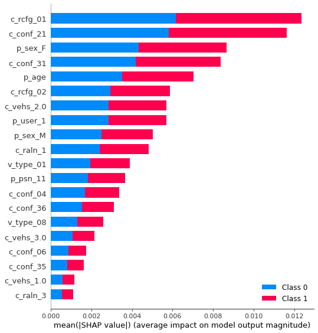

```python
shap.summary_plot(shap_values, x_train, plot_type="bar")
```

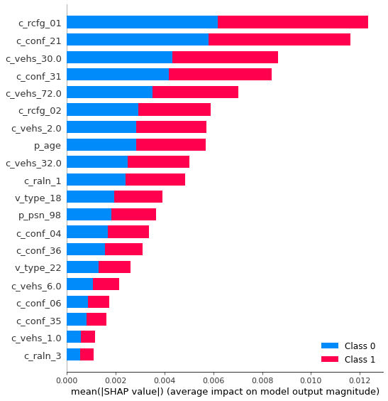

```python
f = plt.figure()
shap.summary_plot(shap_values, x_test)
```